# ESM 232 Final Project

# Barley Results

To test the function, the barely function was run for a period of 100 years. This is an example distribution from the function, the individual input will vary once a part of the larger decision model.

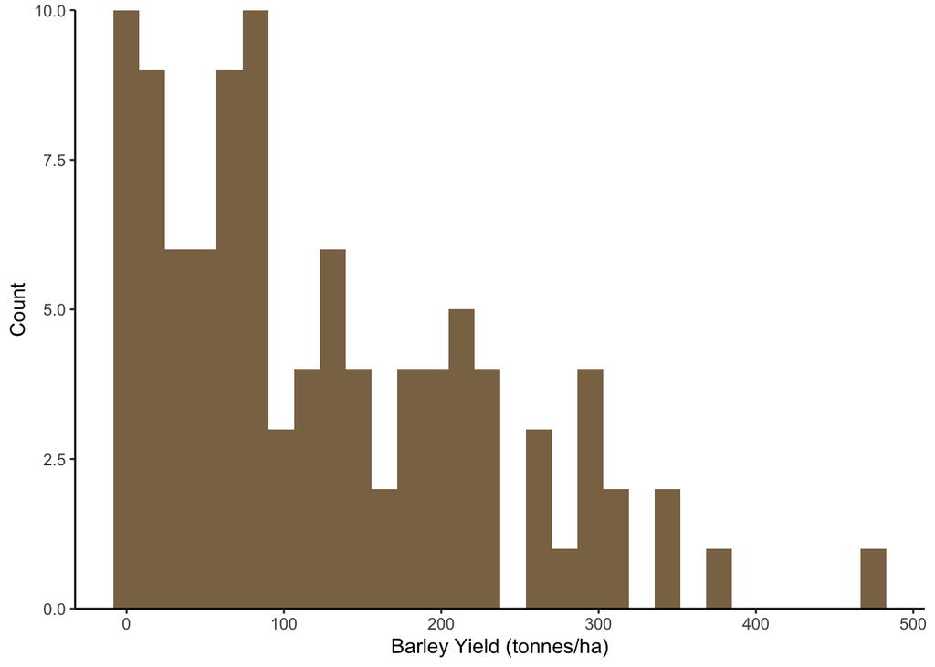

## Livestock component

We’re only interested in herd growth during one time step, and input parameters, especially fertility and survivability might be modified depending on the goals of the farmer. Here, we’ve modified the function evolve_pop to account for additional herd reductions from slaughter. Two offtake rates are considered: 50% and 75% use rates for exploiting natural deaths for caloric gain. These figures variably affect different age categories each with its own fertility rate. Offtake for slaughter may have down-the-line consequences for herd size.

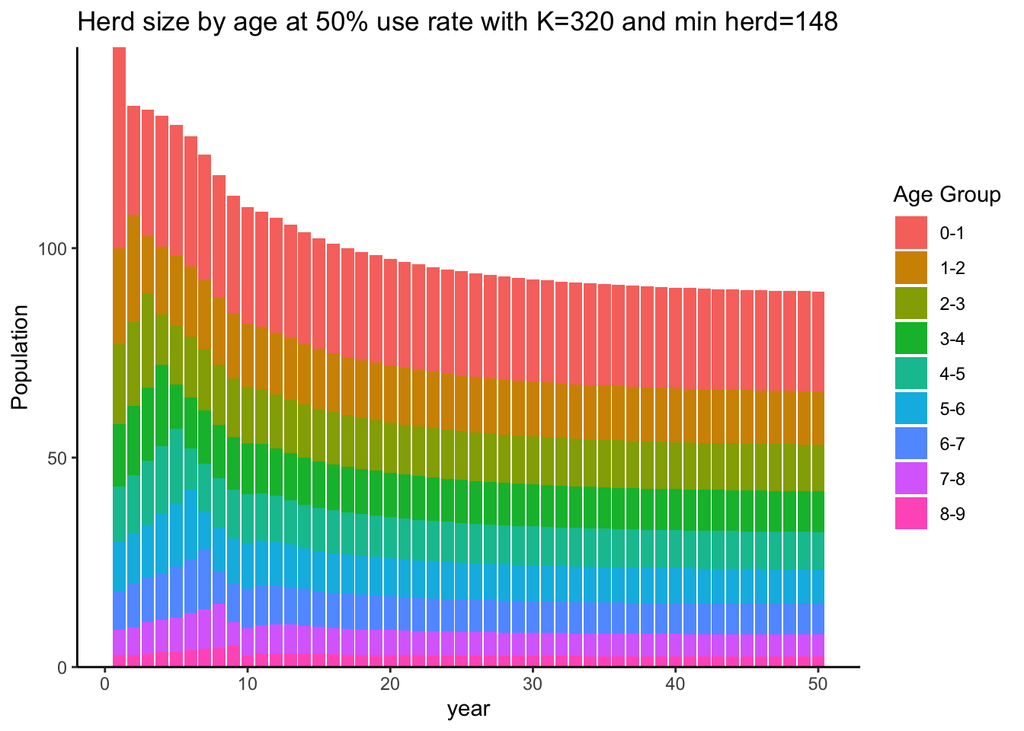

[figure not shown]

## Offtake trends for both strategies

Depending on the strategy, there may be long term offtake trends. These will lead to different availabilities of meat over time.

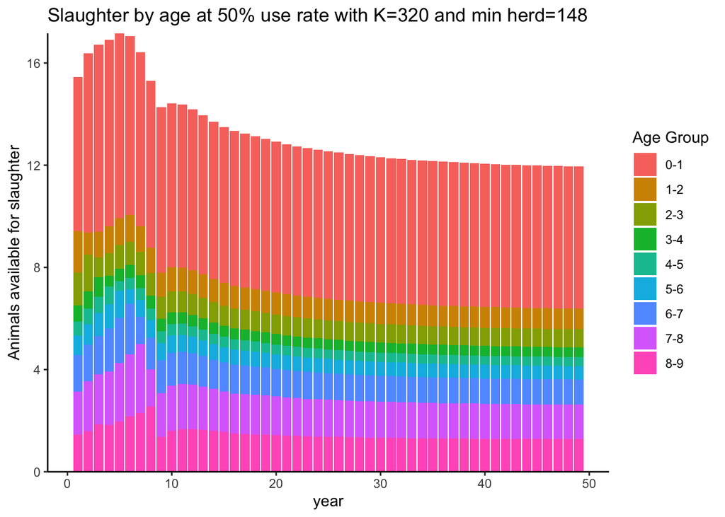

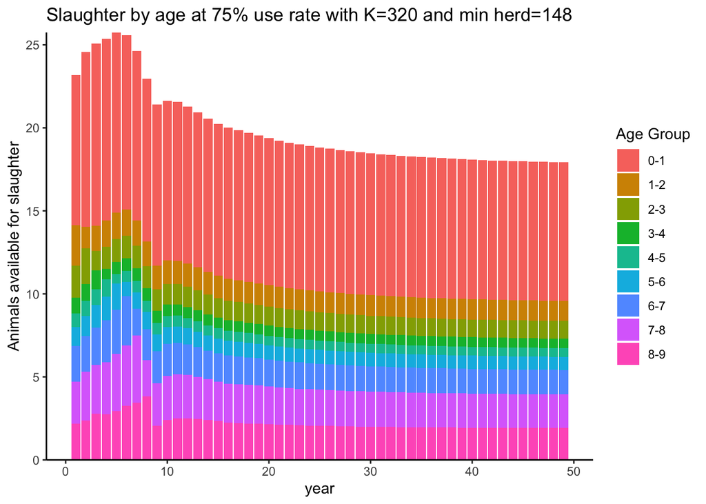